# Saas/Ecommerce-cohort-retention & CLTV_Project

## Day 10- PowerBI Dashboard Preparation

```python
# import required Libraries & load file

import matplotlib.pyplot as plt
import seaborn as sns
import pandas as pd
import numpy as np

file_path = r"C:\Users\LENOVO\Desktop\Saas-Ecommerce-cohort-retention-CLTV_Project\data\processed\customer_cltv_segments.csv"

df = pd.read_csv(file_path)

print(df.shape)

df.head()
```

```
(5878, 6)
```

|  | Customer ID | Revenue | Total_Orders | AOV | CLTV | CLTV_Segment |
| --- | --- | --- | --- | --- | --- | --- |
| 0 | 12346.0 | 77556.46 | 12 | 6463.038333 | 82187.988338 | A |
| 1 | 12347.0 | 4921.53 | 8 | 615.191250 | 7823.152003 | A |
| 2 | 12348.0 | 2019.40 | 5 | 403.880000 | 5135.987599 | B |
| 3 | 12349.0 | 4428.69 | 4 | 1107.172500 | 14079.489526 | A |
| 4 | 12350.0 | 334.40 | 1 | 334.400000 | 4252.436994 | B |

```python
# ==================================================
# DATASET OVERVIEW
# ==================================================

df.info()
```

```
<class 'pandas.DataFrame'>
RangeIndex: 5878 entries, 0 to 5877
Data columns (total 6 columns):
 #   Column        Non-Null Count  Dtype
---  ------        --------------  -----
 0   Customer ID   5878 non-null   float64
 1   Revenue       5878 non-null   float64
 2   Total_Orders  5878 non-null   int64
 3   AOV           5878 non-null   float64
 4   CLTV          5878 non-null   float64
 5   CLTV_Segment  5878 non-null   str
dtypes: float64(4), int64(1), str(1)
memory usage: 275.7 KB
```

```python
# ==================================================
# CHECK MISSING VALUES
# ==================================================

df.isnull().sum()
```

```
Customer ID     0
Revenue         0
Total_Orders    0
AOV             0
CLTV            0
CLTV_Segment    0
dtype: int64
```

```python
# ==================================================
# BASIC NUMERICAL SUMMARY
# ==================================================

df.describe().round(2)
```

|  | Customer ID | Revenue | Total_Orders | AOV | CLTV |
| --- | --- | --- | --- | --- | --- |
| count | 5878.00 | 5878.00 | 5878.00 | 5878.00 | 5878.00 |
| mean | 15315.31 | 2955.90 | 6.29 | 385.18 | 4898.20 |
| std | 1715.57 | 14440.85 | 13.01 | 1214.29 | 15441.62 |
| min | 12346.00 | 2.95 | 1.00 | 2.95 | 37.51 |
| 25% | 13833.25 | 342.28 | 1.00 | 176.68 | 2246.80 |
| 50% | 15314.50 | 867.74 | 3.00 | 279.24 | 3551.02 |
| 75% | 16797.75 | 2248.30 | 7.00 | 414.90 | 5276.16 |
| max | 18287.00 | 580987.04 | 398.00 | 84236.25 | 1071200.20 |

```python
# ==================================================
# SEGMENT DISTRIBUTION
# ==================================================

df["CLTV_Segment"].value_counts()
```

```
CLTV_Segment
A    1470
D    1470
B    1469
C    1469
Name: count, dtype: int64
```

```python
# ==================================================
# CUSTOMER PERCENTAGE BY SEGMENT
# ==================================================

segment_pct = (
    df["CLTV_Segment"]
    .value_counts(normalize=True)
    .mul(100)
    .round(2)
)

segment_pct
```

```
CLTV_Segment
A    25.01
D    25.01
B    24.99
C    24.99
Name: proportion, dtype: float64
```

```python
# ==================================================
# TOTAL REVENUE KPI
# ==================================================

total_revenue = round(df["Revenue"].sum(), 2)

print(total_revenue)
```

```
17374804.27
```

```python
# ==================================================
# TOTAL CUSTOMERS KPI
# ==================================================

total_customers = df["Customer ID"].nunique()

print(total_customers)
```

```
5878
```

```python
# ==================================================
# KPI 1 - TOTAL REVENUE
# ==================================================

total_revenue = round(df["Revenue"].sum(), 2)

print(total_revenue)
```

```
17374804.27
```

```python
# ==================================================
# KPI 2 - TOTAL CUSTOMERS
# ==================================================

total_customers = df["Customer ID"].nunique()

print(total_customers)
```

```
5878
```

```python
# ==================================================
# KPI 3 - AVERAGE CLTV
# ==================================================

avg_cltv = round(df["CLTV"].mean(), 2)

print(avg_cltv)
```

```
4898.2
```

```python
# ==================================================
# KPI 4 - AVERAGE REVENUE PER CUSTOMER
# ==================================================

avg_revenue = round(df["Revenue"].mean(), 2)

print(avg_revenue)
```

```
2955.9
```

```python
# ==================================================
# KPI 5 - TOP CUSTOMER SEGMENT
# ==================================================

top_segment = (
    df.groupby("CLTV_Segment")["Revenue"]
      .sum()
      .idxmax()
)

print(top_segment)
```

```
A
```

```python
# ==================================================
# CREATE KPI DASHBOARD TABLE
# ==================================================

kpi_dashboard = pd.DataFrame({
    "Metric":[
        "Total Revenue",
        "Total Customers",
        "Average CLTV",
        "Average Revenue",
        "Top Segment"
    ],
    "Value":[
        total_revenue,
        total_customers,
        avg_cltv,
        avg_revenue,
        top_segment
    ]
})

kpi_dashboard
```

|  | Metric | Value |
| --- | --- | --- |
| 0 | Total Revenue | 17374804.27 |
| 1 | Total Customers | 5878 |
| 2 | Average CLTV | 4898.2 |
| 3 | Average Revenue | 2955.9 |
| 4 | Top Segment | A |

```python
# ==================================================
# SEGMENT WISE REVENUE
# ==================================================

segment_revenue = (
    df.groupby("CLTV_Segment")["Revenue"]
      .sum()
      .sort_values(ascending=False)
)

segment_revenue
```

```
CLTV_Segment
A    1.132433e+07
B    3.397292e+06
C    1.883001e+06
D    7.701830e+05
Name: Revenue, dtype: float64
```

```python
# ==================================================
# SEGMENT WISE CLTV
# ==================================================

segment_cltv = (
    df.groupby("CLTV_Segment")["CLTV"]
      .sum()
      .sort_values(ascending=False)
)

segment_cltv
```

```
CLTV_Segment
A    1.597220e+07
B    6.331106e+06
C    4.212477e+06
D    2.275819e+06
Name: CLTV, dtype: float64
```

```python
# ==================================================
# CUSTOMER DISTRIBUTION BY SEGMENT
# ==================================================

customer_distribution = (
    df["CLTV_Segment"]
    .value_counts()
    .sort_index()
)

customer_distribution
```

```
CLTV_Segment
A    1470
B    1469
C    1469
D    1470
Name: count, dtype: int64
```

```python
# ==================================================
# CUSTOMER DISTRIBUTION %
# ==================================================

customer_distribution_pct = (
    df["CLTV_Segment"]
    .value_counts(normalize=True)
    .mul(100)
    .round(2)
    .sort_index()
)

customer_distribution_pct
```

```
CLTV_Segment
A    25.01
B    24.99
C    24.99
D    25.01
Name: proportion, dtype: float64
```

```python
# ==================================================
# TOP 10 CUSTOMERS BY CLTV
# ==================================================

top_10_customers = (
    df.sort_values(
        by="CLTV",
        ascending=False
    )
    .head(10)
)

top_10_customers
```

|  | Customer ID | Revenue | Total_Orders | AOV | CLTV | CLTV_Segment |
| --- | --- | --- | --- | --- | --- | --- |
| 4061 | 16446.0 | 168472.50 | 2 | 84236.250000 | 1.071200e+06 | A |
| 3371 | 15749.0 | 44534.30 | 3 | 14844.766667 | 1.887752e+05 | A |
| 2722 | 15098.0 | 39916.50 | 3 | 13305.500000 | 1.692010e+05 | A |
| 1324 | 13687.0 | 11880.84 | 1 | 11880.840000 | 1.510841e+05 | A |
| 569 | 12918.0 | 10953.50 | 1 | 10953.500000 | 1.392915e+05 | A |
| 5642 | 18052.0 | 10877.18 | 1 | 10877.180000 | 1.383209e+05 | A |
| 3382 | 15760.0 | 13916.34 | 2 | 6958.170000 | 8.848439e+04 | A |
| 1538 | 13902.0 | 34095.26 | 5 | 6819.052000 | 8.671528e+04 | A |
| 0 | 12346.0 | 77556.46 | 12 | 6463.038333 | 8.218799e+04 | A |
| 11 | 12357.0 | 18287.66 | 3 | 6095.886667 | 7.751906e+04 | A |

```python
# ==================================================
# SEGMENT WISE AVERAGE METRICS
# ==================================================

segment_avg_metrics = (
    df.groupby("CLTV_Segment")
    .agg({
        "Revenue":"mean",
        "CLTV":"mean",
        "Total_Orders":"mean",
        "AOV":"mean"
    })
    .round(2)
)

segment_avg_metrics
```

| CLTV_Segment | Revenue | CLTV | Total_Orders | AOV |
| --- | --- | --- | --- | --- |
| A | 7703.62 | 10865.44 | 8.73 | 854.43 |
| B | 2312.66 | 4309.81 | 6.80 | 338.91 |
| C | 1281.83 | 2867.58 | 5.66 | 225.50 |
| D | 523.93 | 1548.18 | 3.96 | 121.74 |

```python
# ==================================================
# REVENUE CONTRIBUTION %
# ==================================================

revenue_pct = (
    df.groupby("CLTV_Segment")["Revenue"]
    .sum()
    .div(df["Revenue"].sum())
    .mul(100)
    .round(2)
)

revenue_pct
```

```
CLTV_Segment
A    65.18
B    19.55
C    10.84
D     4.43
Name: Revenue, dtype: float64
```

```python
# ==================================================
# CLTV CONTRIBUTION %
# ==================================================

cltv_pct = (
    df.groupby("CLTV_Segment")["CLTV"]
    .sum()
    .div(df["CLTV"].sum())
    .mul(100)
    .round(2)
)

cltv_pct
```

```
CLTV_Segment
A    55.48
B    21.99
C    14.63
D     7.90
Name: CLTV, dtype: float64
```

```python
# ==================================================
# DASHBOARD VISUAL SUMMARY TABLE
# ==================================================

dashboard_visuals = pd.DataFrame({
    "Revenue_%": revenue_pct,
    "CLTV_%": cltv_pct
})

dashboard_visuals
```

| CLTV_Segment | Revenue_% | CLTV_% |
| --- | --- | --- |
| A | 65.18 | 55.48 |
| B | 19.55 | 21.99 |
| C | 10.84 | 14.63 |
| D | 4.43 | 7.90 |

```python
# ==================================================
# DASHBOARD VISUAL SUMMARY TABLE SHAPE
# ==================================================

dashboard_visuals.shape
```

```
(4, 2)
```

```python
# ==================================================
# TAG: Segment Customer Distribution Analysis
# ==================================================

segment_customer_pct = (
    df["CLTV_Segment"]
    .value_counts(normalize=True)
    .sort_index() * 100
).round(2)

segment_customer_pct
```

```
CLTV_Segment
A    25.01
B    24.99
C    24.99
D    25.01
Name: proportion, dtype: float64
```

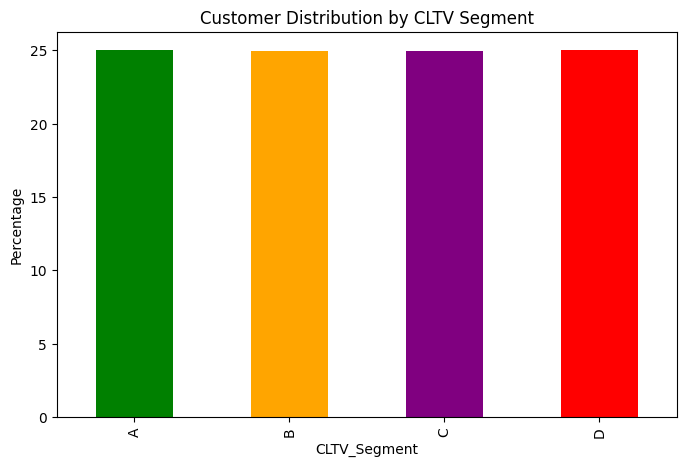

```python
# ==================================================
# TAG: Customer Distribution Visualization
# ==================================================

import matplotlib.pyplot as plt

segment_customer_pct.plot(
    kind="bar",
    figsize=(8,5),
    color=["green","orange","purple","red"]
)

plt.title("Customer Distribution by CLTV Segment")
plt.ylabel("Percentage")
plt.show()
```

```python
# ==================================================
# TAG: Revenue Concentration Analysis
# ==================================================

top_segment_revenue_share = revenue_pct.loc["A"]

print(f"Segment A contributes {top_segment_revenue_share:.2f}% of total revenue")
```

```
Segment A contributes 65.18% of total revenue
```

```python
# ==================================================
# TAG: CLTV Concentration Analysis
# ==================================================

top_segment_cltv_share = cltv_pct.loc["A"]

print(f"Segment A contributes {top_segment_cltv_share:.2f}% of total CLTV")
```

```
Segment A contributes 55.48% of total CLTV
```

```python
# ==================================================
# TAG: Revenue Efficiency Gap
# ==================================================

efficiency_gap = revenue_pct - cltv_pct

efficiency_gap.round(2)
```

```
CLTV_Segment
A    9.70
B   -2.44
C   -3.79
D   -3.47
dtype: float64
```

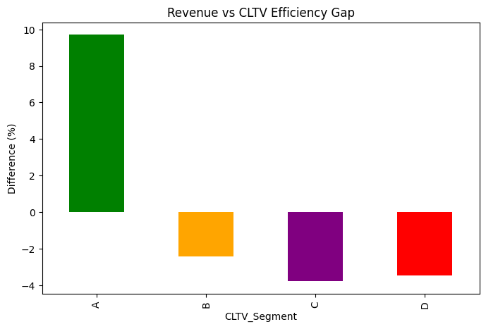

```python
# ==================================================
# TAG: Efficiency Gap Visualization
# ==================================================

efficiency_gap.plot(
    kind="bar",
    figsize=(8,5),
    color=["green","orange","purple","red"]
)

plt.title("Revenue vs CLTV Efficiency Gap")
plt.ylabel("Difference (%)")
plt.show()
```

```python
# ==================================================
# TAG: Business Interpretation Table
# ==================================================

business_story = pd.DataFrame({
    "Revenue_%": revenue_pct,
    "CLTV_%": cltv_pct,
    "Insight": [
        "Premium Customers",
        "Upsell Opportunity",
        "Growth Opportunity",
        "Reactivation Target"
    ]
})

business_story
```

| CLTV_Segment | Revenue_% | CLTV_% | Insight |
| --- | --- | --- | --- |
| A | 65.18 | 55.48 | Premium Customers |
| B | 19.55 | 21.99 | Upsell Opportunity |
| C | 10.84 | 14.63 | Growth Opportunity |
| D | 4.43 | 7.90 | Reactivation Target |

```python
# ==================================================
# TAG: Dashboard Visual Summary Table Shape
# ==================================================

business_story.shape
```

```
(4, 3)
```

```python
# ==================================================
# TAG: Create Business Recommendation Table
# ==================================================

recommendations = pd.DataFrame({
    "Recommendation":[
        "Retain Segment A Customers",
        "Upsell Segment B Customers",
        "Engage Segment C Customers",
        "Reactivate Segment D Customers"
    ]
})

recommendations
```

|  | Recommendation |
| --- | --- |
| 0 | Retain Segment A Customers |
| 1 | Upsell Segment B Customers |
| 2 | Engage Segment C Customers |
| 3 | Reactivate Segment D Customers |

```python
# ==================================================
# TAG: Check Recommendation Table Shape
# ==================================================

recommendations.shape
```

```
(4, 1)
```

```python
# ==================================================
# TAG: Create Executive KPI Table
# ==================================================

executive_summary = pd.DataFrame({
    "Metric":[
        "Total Revenue",
        "Total Customers",
        "Average CLTV",
        "Average Revenue",
        "Top Segment"
    ],
    "Value":[
        round(df["Revenue"].sum(),2),
        df.shape[0],
        round(df["CLTV"].mean(),2),
        round(df["Revenue"].mean(),2),
        "A"
    ]
})

executive_summary
```

|  | Metric | Value |
| --- | --- | --- |
| 0 | Total Revenue | 17374804.27 |
| 1 | Total Customers | 5878 |
| 2 | Average CLTV | 4898.2 |
| 3 | Average Revenue | 2955.9 |
| 4 | Top Segment | A |

```python
# ==================================================
# TAG: Executive Summary Shape Check
# ==================================================

executive_summary.shape
```

```
(5, 2)
```

```python
# ==================================================
# TAG: Top Segment Revenue Contribution
# ==================================================

round(revenue_pct.loc["A"],2)
```

```
np.float64(65.18)
```

```python
# ==================================================
# TAG: Top Segment CLTV Contribution
# ==================================================

round(cltv_pct.loc["A"],2)
```

```
np.float64(55.48)
```

```python
# ==================================================
# TAG: Save Business Story Table
# ==================================================

business_story.to_csv(
    r"C:\Users\LENOVO\Desktop\Saas-Ecommerce-cohort-retention-CLTV_Project\data\processed\business_story.csv",
    index=True
)

print("business_story.csv saved successfully")
```

```
business_story.csv saved successfully
```

```python
# ==================================================
# TAG: Save Recommendations Table
# ==================================================

recommendations.to_csv(
    r"C:\Users\LENOVO\Desktop\Saas-Ecommerce-cohort-retention-CLTV_Project\data\processed\business_recommendations_v2.csv",
    index=False
)

print("business_recommendations_v2.csv saved successfully")
```

```
business_recommendations_v2.csv saved successfully
```

```python
# ==================================================
# TAG: Verify Saved Files
# ==================================================

import os

processed_path = r"C:\Users\LENOVO\Desktop\Saas-Ecommerce-cohort-retention-CLTV_Project\data\processed"

sorted(os.listdir(processed_path))
```

```
['business_recommendations.csv',
 'business_recommendations_v2.csv',
 'business_story.csv',
 'cltv_base_data.csv',
 'cohort_prepared_data.csv',
 'customer_cltv_segments.csv',
 'executive_summary.csv',
 'pareto_analysis.csv',
 'retention_base_table.csv',
 'retention_count_matrix.csv',
 'retention_percentage_matrix.csv',
 'segment_insights.csv',
 'segment_kpi_dashboard.csv',
 'segment_summary.csv']
```

```python
# ==================================================
# TAG: Load Saved Business Story For Validation
# ==================================================

check_story = pd.read_csv(
    r"C:\Users\LENOVO\Desktop\Saas-Ecommerce-cohort-retention-CLTV_Project\data\processed\business_story.csv"
)

check_story.head()
```

|  | CLTV_Segment | Revenue_% | CLTV_% | Insight |
| --- | --- | --- | --- | --- |
| 0 | A | 65.18 | 55.48 | Premium Customers |
| 1 | B | 19.55 | 21.99 | Upsell Opportunity |
| 2 | C | 10.84 | 14.63 | Growth Opportunity |
| 3 | D | 4.43 | 7.90 | Reactivation Target |

```python
# ==================================================
# TAG: Load Saved Recommendations For Validation
# ==================================================

check_reco = pd.read_csv(
    r"C:\Users\LENOVO\Desktop\Saas-Ecommerce-cohort-retention-CLTV_Project\data\processed\business_recommendations_v2.csv"
)

check_reco.head()
```

|  | Recommendation |
| --- | --- |
| 0 | Retain Segment A Customers |
| 1 | Upsell Segment B Customers |
| 2 | Engage Segment C Customers |
| 3 | Reactivate Segment D Customers |

# Business Insights & Executive Reporting Analysis

## Objective

Build a business-focused reporting layer on top of CLTV segmentation results to generate executive summaries, customer insights, revenue contribution analysis, and strategic recommendations.

## Step 1: Load Customer CLTV Dataset

- Loaded `customer_cltv_segments.csv`
- Verified shape, columns, and data types
- Reviewed customer-level Revenue, Orders, AOV, CLTV, and Segment data

## Step 2: Executive KPI Analysis

Created high-level business KPIs:

- Total Revenue
- Total Customers
- Average Revenue per Customer
- Average CLTV
- Top Revenue Segment

Generated executive summary table for management reporting.

## Step 3: Revenue & CLTV Contribution Analysis

Calculated:

- Revenue contribution percentage by segment
- CLTV contribution percentage by segment

Key Finding:

- Segment A contributes 65.18% of total revenue
- Segment A contributes 55.48% of total CLTV

## Step 4: Segment Performance Evaluation

Compared:

- Average Revenue
- Average Orders
- Average AOV
- Average CLTV

Across:

- Segment A
- Segment B
- Segment C
- Segment D

## Step 5: Customer Distribution Analysis

Analyzed customer distribution across all segments.

Result:

- Nearly equal customer distribution (~25% each segment)

## Step 6: Revenue vs CLTV Efficiency Analysis

Calculated efficiency gap:

Efficiency Gap = Revenue % − CLTV %

Insights:

- Segment A = Strongest performing segment
- Segments B, C, D = Future growth opportunities

## Step 7: Business Story Framework

Created strategic interpretation table:

- A → Premium Customers
- B → Upsell Opportunity
- C → Growth Opportunity
- D → Reactivation Target

## Step 8: Recommendation Framework

Generated actionable recommendations:

- Retain Segment A Customers
- Upsell Segment B Customers
- Engage Segment C Customers
- Reactivate Segment D Customers

## Step 9: Save Final Outputs

Saved:

- business_story.csv
- business_recommendations_v2.csv

into the processed folder.

## Step 10: Validation & Cross Check

- Verified saved files
- Reloaded files
- Checked shapes and contents
- Confirmed successful storage for Power BI reporting phase

## Outcome

Successfully completed the Business Insights & Executive Reporting layer for the SaaS E-commerce Cohort Retention & CLTV Project. The project now includes customer segmentation, executive KPIs, business recommendations, revenue contribution analysis, and management-ready reporting datasets.